# Kaggle Macro Data EDA, Cleaning

Wes Aull

May 16, 2017

Joining the critical price data to the macro data:

```r
macro = left_join(price,macro, by = 'timestamp')
rm(price)
```

*Initial Read in and View of Macro CSV*

The macroeconomic data csv is read as a dataframe. Variables properly classified with zero problems (using readr library).

The data set is made up of 2,484 observations (daily from 1-1-2010 to 10-19-2016) for 100 variables, spanning commodity prices, exchange rates, national demographic data, average rent for apartments of 2,3,4 BR, and others.

The numbers above do not include the key variables imported from the Kaggle training data set. I’ve joined these for sake of experimental modelling and dimension reduction to extract worthwhile information from the macro database.

After completing one iteration of this document, it became apparent to me that I should attempt to allocate the fields for rent for a 2,3,4 BR according to the square footage of the apt. I’m hopeful this will at least boost the linear regression. I create a mutated field in dplyr assigning the appropriate rent by a rough heuristic for each apartment below:

```r
macro = macro %>%
  mutate(rent = ifelse(full_sq <= 50,(rent_price_1room_bus+rent_price_1room_eco)/2,ifelse(full_sq <= 80,(rent_price_2room_bus+rent_price_2room_eco)/2,ifelse(full_sq <= 110,(rent_price_3room_bus+rent_price_3room_eco)/2,(rent_price_3room_bus+rent_price_3room_eco)/1.5))))
```

*Inspection of NA’s:*

Let’s look at the NA count per variable.

```
##                                  timestamp
##                                          0
##                                  price_doc
##                                          0
##                                    full_sq
##                                          0
##                                    life_sq
##                                       6383
##                                      floor
##                                        167
##                                  max_floor
##                                       9572
##                                 build_year
##                                      13605
##                                  oil_urals
##                                          0
##                                  gdp_quart
##                                          0
##                           gdp_quart_growth
##                                          0
##                                        cpi
##                                          0
##                                        ppi
##                                          0
##                               gdp_deflator
##                                          0
##                              balance_trade
##                                          0
##                       balance_trade_growth
##                                          0
##                                     usdrub
##                                          0
##                                     eurrub
##                                          0
##                                      brent
##                                          0
##                         net_capital_export
##                                          0
##                                 gdp_annual
##                                          0
```

[output cut: 169 more lines]

```
##                                       3239
##                         apartment_fund_sqm
##                                          0
##                                  brent_yoy
##                                          0
##                                 usdrub_yoy
##                                          0
##                                    ppi_yoy
##                                          0
##                                    cpi_yoy
##                                          0
##                          mortgage_rate_yoy
##                                          0
##                                       rent
##                                          0
```

The macro data set has significant missing values. 9 out of 100 variables have 40%+ observations that are NA. 12 out of 100 variables have ~25%+ observations that are NA. Inspecting these 12, I don’t believe them to be critical indicators or ones that contain a great amount of data.

There’s a large set of variables that would seem worthwhile with 1-2 years data missing at the beginning or end of the time series (15 - 25% NA). They tend to be quarterly data series that are simply repeated every observation until the next quarter release.

This data is difficult to impute because it is such a large portion of the observations. The data is also time dependent and in one large cluster for most variables.

I’d like to simply impute in a way that doesn’t reinforce trends in existing data but let the remaining data in the observations stand. I duplicate data set for cleaning and throw out all variables with more than 13,606 observations missing (>40%). The full, incomplete data set can be considered at a later point for modelling.

```r
# For loop counting backwards to delete columns with more than 659 missing obs.
data = macro
for (i in seq(ncol(data),1)) {
  if (sum(is.na(data[,i])) > 13606) {
    data[,i] = NULL
  }
}
```

*Inspection of Variables:*

```r
summary(data)
```

```
##    timestamp            price_doc            full_sq
##  Min.   :2011-08-20   Min.   :   100000   Min.   :   0.00
##  1st Qu.:2013-04-25   1st Qu.:  4740002   1st Qu.:  38.00
##  Median :2014-02-19   Median :  6274411   Median :  49.00
##  Mean   :2013-12-21   Mean   :  7123035   Mean   :  54.21
##  3rd Qu.:2014-09-24   3rd Qu.:  8300000   3rd Qu.:  63.00
##  Max.   :2015-06-30   Max.   :111111112   Max.   :5326.00
##
##     life_sq           floor          max_floor        build_year
##  Min.   :   0.0   Min.   : 0.000   Min.   :  0.00   Min.   :       0
##  1st Qu.:  20.0   1st Qu.: 3.000   1st Qu.:  9.00   1st Qu.:    1967
##  Median :  30.0   Median : 6.500   Median : 12.00   Median :    1979
##  Mean   :  34.4   Mean   : 7.671   Mean   : 12.56   Mean   :    3068
##  3rd Qu.:  43.0   3rd Qu.:11.000   3rd Qu.: 17.00   3rd Qu.:    2005
##  Max.   :7478.0   Max.   :77.000   Max.   :117.00   Max.   :20052009
##  NA's   :6383     NA's   :167      NA's   :9572     NA's   :13605
##    oil_urals        gdp_quart     gdp_quart_growth      cpi
##  Min.   : 46.34   Min.   :14314   Min.   :-2.800   Min.   :353.0
##  1st Qu.: 93.74   1st Qu.:17015   1st Qu.: 0.700   1st Qu.:388.5
##  Median :107.20   Median :18411   Median : 0.900   Median :408.3
##  Mean   : 97.70   Mean   :18217   Mean   : 1.444   Mean   :411.7
##  3rd Qu.:108.65   3rd Qu.:19566   3rd Qu.: 2.100   3rd Qu.:428.6
##  Max.   :122.52   Max.   :21515   Max.   : 5.200   Max.   :489.5
##
##       ppi         gdp_deflator    balance_trade   balance_trade_growth
##  Min.   :420.7   Min.   : 86.72   Min.   :12.79   Min.   : 4.60
##  1st Qu.:472.2   1st Qu.:108.30   1st Qu.:15.75   1st Qu.: 7.60
##  Median :487.9   Median :113.47   Median :16.95   Median :16.80
##  Mean   :492.2   Mean   :110.40   Mean   :17.49   Mean   :22.61
##  3rd Qu.:510.1   3rd Qu.:113.47   3rd Qu.:19.64   3rd Qu.:32.90
##  Max.   :575.9   Max.   :123.66   Max.   :21.94   Max.   :75.80
##
##      usdrub          eurrub          brent        net_capital_export
##  Min.   :28.81   Min.   :38.43   Min.   : 46.59   Min.   :-0.27712
##  1st Qu.:31.93   1st Qu.:41.59   1st Qu.: 96.85   1st Qu.:-0.16905
##  Median :34.38   Median :46.82   Median :107.44   Median : 0.04836
##  Mean   :38.03   Mean   :48.76   Mean   : 98.83   Mean   : 0.01810
##  3rd Qu.:38.59   3rd Qu.:50.22   3rd Qu.:109.97   3rd Qu.: 0.16978
##  Max.   :69.47   Max.   :84.96   Max.   :126.22   Max.   : 0.61439
##
```

[output cut: 209 more lines]

```
##  Min.   :226047     Min.   :-0.56356   Min.   :-0.05990
##  1st Qu.:226047     1st Qu.:-0.15468   1st Qu.: 0.03610
##  Median :229295     Median :-0.03244   Median : 0.09733
##  Mean   :229594     Mean   :-0.09125   Mean   : 0.19366
##  3rd Qu.:232840     3rd Qu.: 0.02752   3rd Qu.: 0.21279
##  Max.   :234577     Max.   : 0.49692   Max.   : 1.06422
##
##     ppi_yoy           cpi_yoy        mortgage_rate_yoy        rent
##  Min.   :0.01061   Min.   :0.03086   Min.   :-0.124811   Min.   : 27.04
##  1st Qu.:0.03673   1st Qu.:0.06447   1st Qu.:-0.032309   1st Qu.: 45.27
##  Median :0.05315   Median :0.07025   Median : 0.005659   Median : 51.75
##  Mean   :0.06167   Mean   :0.07775   Mean   : 0.018209   Mean   : 53.15
##  3rd Qu.:0.07803   3rd Qu.:0.07803   3rd Qu.: 0.057837   3rd Qu.: 58.00
##  Max.   :0.18325   Max.   :0.16928   Max.   : 0.228070   Max.   :124.77
##
```

There’s a good amount of variables that reflect the same data. GDP Deflator, CPI, and PPI should have correlations very close to one. Brent and Ural prices should correlate very close to one. The same can be said for different economic measures of activity and income.

Before making more difficult decisions on imputation, I’d like to play with a few models to see what set should obviously be pared away for a clean / low-dimension data set with collinearities removed.

I’d rather use the complete observations paired with common sense to conservatively pare any variables, which I draw below. The complete observations for all variables are ~40% of the data set.

I also standardize the data by its standard deviation and mean using the caret’s preProcess function. I had difficult implementing a YeoJohnson transformation for any variables where possible (essentially Box Cox that’s allowed on negative numbers). I will return to this.

```r
complete_data = data[complete.cases(data),]
complete_data$baths_share = NULL
complete_data$water_pipes_share = NULL
complete_data$childbirth = NULL
complete_data$heating_share = NULL
complete_data$hot_water_share = NULL
complete_data$old_house_share = NULL
complete_data$gdp_deflator = NULL
preProcessParameters = preProcess(complete_data[,1:ncol(complete_data)], method = c('center','scale'), n.comp=12)
complete_stand_data = predict(preProcessParameters,complete_data[,1:ncol(complete_data)])
```

It appears that a few variables have the same value throughout the data set. Our model should remove these ultimately. I implemented in the coding above.

I begin modelling with a saturated linear regression model:

```r
saturated_linear_regression = lm(price_doc ~ ., complete_stand_data[,2:ncol(complete_stand_data)])
summary(saturated_linear_regression)
```

```
##
## Call:
## lm(formula = price_doc ~ ., data = complete_stand_data[, 2:ncol(complete_stand_data)])
##
## Residuals:
##      Min       1Q   Median       3Q      Max
## -13.7464  -0.3276   0.0883   0.3111  11.1017
##
## Coefficients: (58 not defined because of singularities)
##                                              Estimate Std. Error t value
## (Intercept)                                -4.706e-03  9.601e-03  -0.490
## full_sq                                     4.323e-01  1.477e-02  29.277
## life_sq                                    -1.828e-02  6.723e-03  -2.719
## floor                                       2.867e-02  7.723e-03   3.712
## max_floor                                   6.984e-03  7.803e-03   0.895
## build_year                                  6.971e-03  6.536e-03   1.066
## oil_urals                                  -9.994e+09  1.933e+11  -0.052
## gdp_quart                                   2.787e+10  3.485e+11   0.080
## gdp_quart_growth                            1.858e+10  9.939e+11   0.019
## cpi                                         1.834e+10  5.872e+10   0.312
## ppi                                         1.110e+09  6.885e+10   0.016
## balance_trade                              -8.186e+09  2.406e+11  -0.034
## balance_trade_growth                        2.078e+10  6.543e+10   0.318
## usdrub                                      2.880e-01  2.487e-01   1.158
## eurrub                                     -1.614e-01  1.410e-01  -1.145
## brent                                      -2.402e-02  7.372e-02  -0.326
## net_capital_export                          1.949e+10  3.662e+11   0.053
## gdp_annual                                 -2.111e+10  3.708e+10  -0.569
## gdp_annual_growth                                  NA         NA      NA
## average_provision_of_build_contract         4.806e+09  9.385e+11   0.005
## average_provision_of_build_contract_moscow -1.756e+09  2.614e+11  -0.007
## rts                                         9.095e-02  1.031e-01   0.882
## micex                                      -1.518e-02  3.911e-02  -0.388
## micex_rgbi_tr                              -2.788e-02  5.036e-02  -0.553
## micex_cbi_tr                                2.815e-03  1.205e-02   0.234
## deposits_value                              8.646e+00  1.254e+01   0.690
## deposits_growth                             3.344e+00  4.629e+00   0.722
## deposits_rate                              -2.332e+08  2.502e+10  -0.009
## mortgage_value                             -5.245e+10  6.413e+11  -0.082
## mortgage_growth                            -4.123e+10  4.136e+11  -0.100
```

[output cut: 156 more lines]

```
## population_reg_sports_share                      NA
## apartment_build                                  NA
## apartment_fund_sqm                               NA
## brent_yoy                                  0.724201
## usdrub_yoy                                 0.902738
## ppi_yoy                                    0.965434
## cpi_yoy                                    0.941785
## mortgage_rate_yoy                                NA
## rent                                        < 2e-16 ***
## ---
## Signif. codes:  0 '***' 0.001 '**' 0.01 '*' 0.05 '.' 0.1 ' ' 1
##
## Residual standard error: 0.7643 on 13688 degrees of freedom
## Multiple R-squared:  0.4175, Adjusted R-squared:  0.4159
## F-statistic: 258.2 on 38 and 13688 DF,  p-value: < 2.2e-16
```

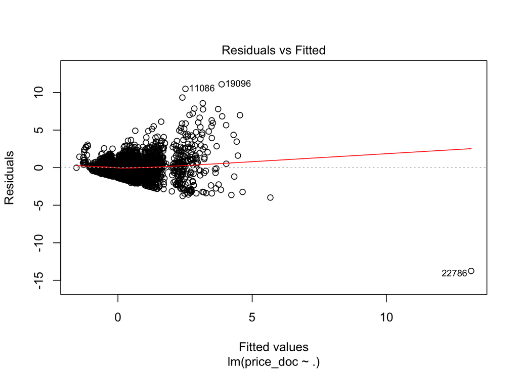

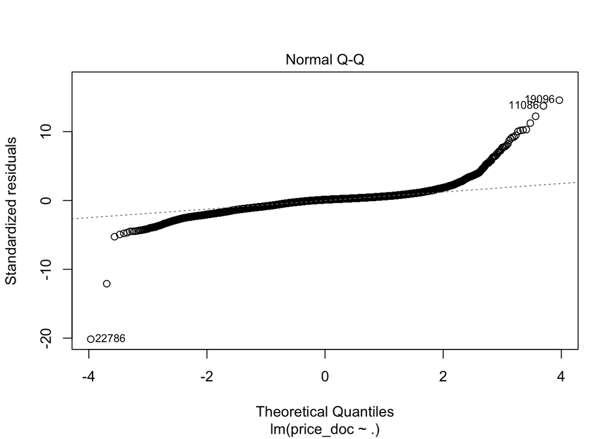

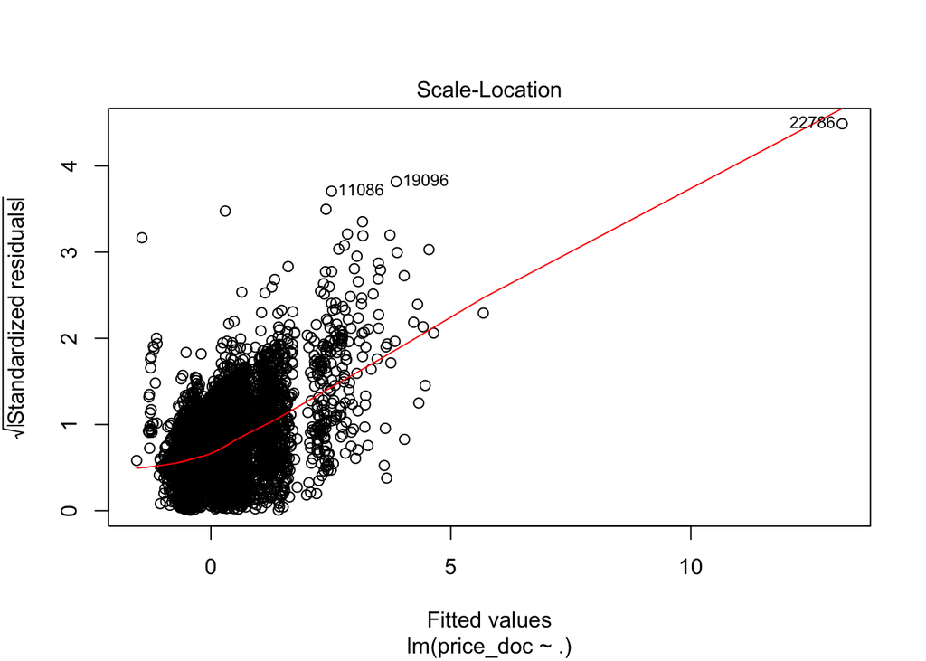

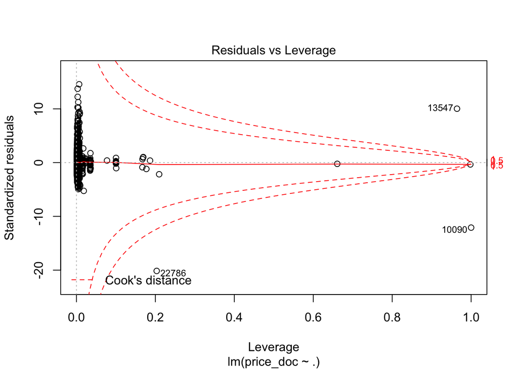

```r
plot(saturated_linear_regression)
```

At face value, the entire macro set has no descriptive power in the initial saturated model. Variance explained was 40.6%. After I made the following changes, the model then improved to:

*After I assigned apartment appropriate rent, the variance explained increased to 42% and rent became the only macro. variable with a significant p value.*

*After I created trailing yoy change for a set of 5-7 important macro variables, the variance slightly diminished to 41.6%. There also appears to be a lot of NA values in the lm model, which are odd.*

There are several reasons that the macro variables were so useless:

- a portion of the macro variables are nowhere near normal and may need special transformation.
- too many highly collinear dimensions are draining any explanatory power from a smaller set.
- the autocorrelations or time-dependent properties of the macro data could have more explanatory power than its values in a given moment.
- outside of time series, *these are quarterly and yearly data series. Their repeated values will be analyzed* *incorrectly for their variance and explanatory power in a data set filled with daily and repeated observations.*

I’ll next use forward and backward stepwise variable selection to see if we how much we can quickly improve the linear regression…and see if any macro variables begin to show significance.

```
## Start:  AIC=1
## price_doc ~ 1
##
##                                              Df Sum of Sq     RSS     AIC
## + full_sq                                     1    5534.6  8191.4 -7082.9
## + rent                                        1    4917.1  8808.9 -6085.3
## + max_floor                                   1     371.1 13354.9  -373.2
## + floor                                       1     273.3 13452.7  -273.1
## + life_sq                                     1     231.1 13494.9  -230.1
## + micex_rgbi_tr                               1      33.1 13692.9   -30.2
## + cpi                                         1      29.4 13696.6   -26.4
## + timestamp                                   1      29.3 13696.7   -26.3
## + rts                                         1      29.2 13696.8   -26.2
## + fixed_basket                                1      28.9 13697.1   -26.0
## + deposits_value                              1      25.4 13700.6   -22.4
## + cpi_yoy                                     1      24.2 13701.8   -21.2
## + ppi                                         1      21.5 13704.5   -18.5
## + eurrub                                      1      21.3 13704.7   -18.3
## + usdrub                                      1      20.4 13705.6   -17.4
## + rent_price_2room_bus                        1      19.1 13706.9   -16.1
## + average_provision_of_build_contract         1      18.9 13707.1   -16.0
## + retail_trade_turnover_growth                1      18.9 13707.1   -15.9
## + divorce_rate                                1      18.9 13707.1   -15.9
## + housing_fund_sqm                            1      18.9 13707.1   -15.9
## + gas_share                                   1      18.9 13707.1   -15.9
## + power_clinics                               1      18.9 13707.1   -15.9
## + turnover_catering_per_cap                   1      18.9 13707.1   -15.9
## + gdp_annual                                  1      18.9 13707.1   -15.9
## + gdp_annual_growth                           1      18.9 13707.1   -15.9
## + grp                                         1      18.9 13707.1   -15.9
## + grp_growth                                  1      18.9 13707.1   -15.9
## + real_dispos_income_per_cap_growth           1      18.9 13707.1   -15.9
## + salary                                      1      18.9 13707.1   -15.9
## + salary_growth                               1      18.9 13707.1   -15.9
## + retail_trade_turnover                       1      18.9 13707.1   -15.9
## + retail_trade_turnover_per_cap               1      18.9 13707.1   -15.9
## + labor_force                                 1      18.9 13707.1   -15.9
## + unemployment                                1      18.9 13707.1   -15.9
## + employment                                  1      18.9 13707.1   -15.9
## + invest_fixed_capital_per_cap                1      18.9 13707.1   -15.9
```

[output cut: 742 more lines]

```
## + deposits_growth                             1   0.02784 8003.9 -7386.9
## + income_per_cap                              1   0.02172 8003.9 -7386.9
## + gdp_quart_growth                            1   0.01499 8003.9 -7386.9
## + rent_price_2room_eco                        1   0.01290 8003.9 -7386.9
## + timestamp                                   1   0.01226 8003.9 -7386.9
## + rent_price_3room_eco                        1   0.00968 8003.9 -7386.9
## + average_provision_of_build_contract         1   0.00742 8003.9 -7386.9
## + mortgage_rate_yoy                           1   0.00541 8003.9 -7386.9
## + mortgage_value                              1   0.00527 8003.9 -7386.9
## + balance_trade_growth                        1   0.00331 8003.9 -7386.9
## + deposits_value                              1   0.00329 8003.9 -7386.9
## + micex                                       1   0.00283 8003.9 -7386.9
## + cpi_yoy                                     1   0.00227 8003.9 -7386.9
## + micex_cbi_tr                                1   0.00166 8003.9 -7386.9
## + mortgage_growth                             1   0.00030 8003.9 -7386.9
```

```r
summary(forwardAIC)
```

```
##
## Call:
## lm(formula = price_doc ~ full_sq + rent + rent_price_1room_bus +
##     floor + micex_rgbi_tr + life_sq + gdp_quart, data = complete_stand_data)
##
## Residuals:
##      Min       1Q   Median       3Q      Max
## -13.7671  -0.3253   0.0891   0.3105  11.1791
##
## Coefficients:
##                        Estimate Std. Error t value Pr(>|t|)
## (Intercept)           3.104e-15  6.519e-03   0.000  1.00000
## full_sq               4.333e-01  1.465e-02  29.582  < 2e-16 ***
## rent                  2.322e-01  1.505e-02  15.428  < 2e-16 ***
## rent_price_1room_bus -4.953e-02  7.932e-03  -6.244 4.38e-10 ***
## floor                 3.253e-02  6.617e-03   4.916 8.92e-07 ***
## micex_rgbi_tr        -3.937e-02  7.938e-03  -4.960 7.15e-07 ***
## life_sq              -1.824e-02  6.709e-03  -2.719  0.00655 **
## gdp_quart            -1.393e-02  7.861e-03  -1.772  0.07634 .
## ---
## Signif. codes:  0 '***' 0.001 '**' 0.01 '*' 0.05 '.' 0.1 ' ' 1
##
## Residual standard error: 0.7638 on 13719 degrees of freedom
## Multiple R-squared:  0.4169, Adjusted R-squared:  0.4166
## F-statistic:  1401 on 7 and 13719 DF,  p-value: < 2.2e-16
```

```r
#summary(backwardAIC)
```

R-squared barely lower than the original saturated model. After making different modifications, this selection set seems to be unstable. I’m beginning to wonder how much dimensionality really can create sub-optimal effects on the modeling process.

*VIF:*

```
##              full_sq                 rent rent_price_1room_bus
##             5.048484             5.327193             1.480247
##                floor        micex_rgbi_tr              life_sq
##             1.030244             1.482604             1.058917
##            gdp_quart
##             1.453948
```

And the plots for the forward stepwise model. Take note of the Influence Plot. Despite the standardized data, there are some *serious* outlier issues with this data set. This has to be contributing to the serious under-performance of the regression model. For an economic valuation time series (value of a real estate asset), 40% variance explained is rather low…even for a noisy economic process:

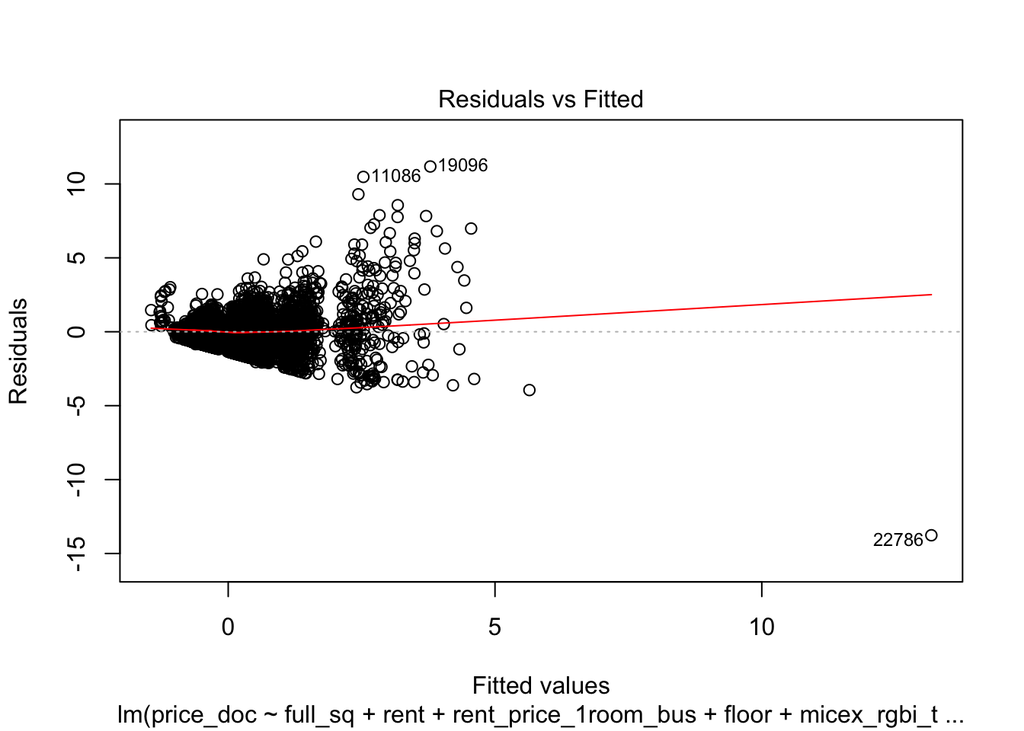

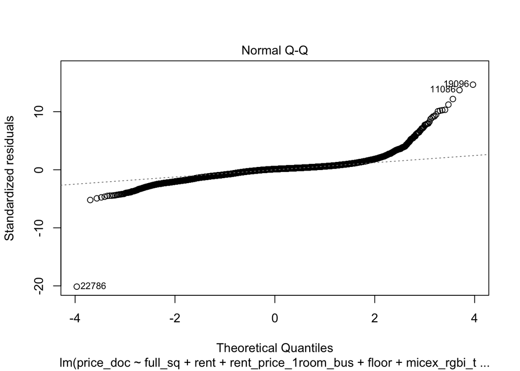

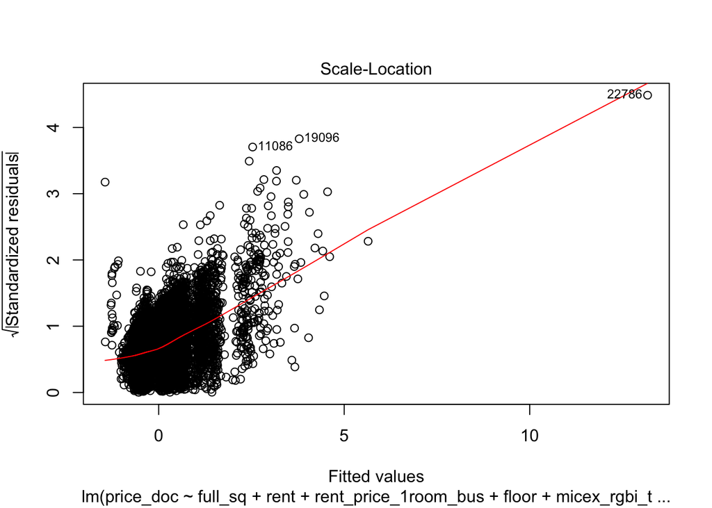

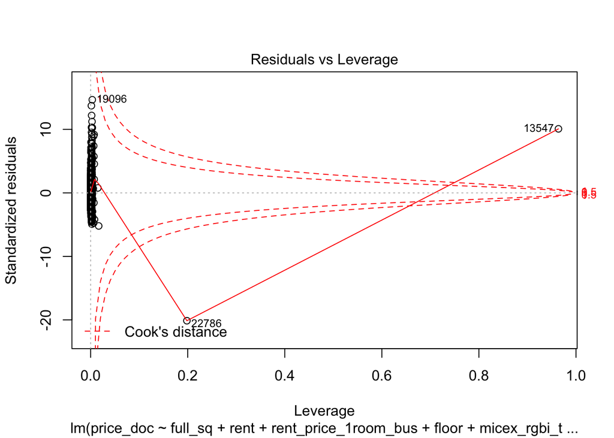

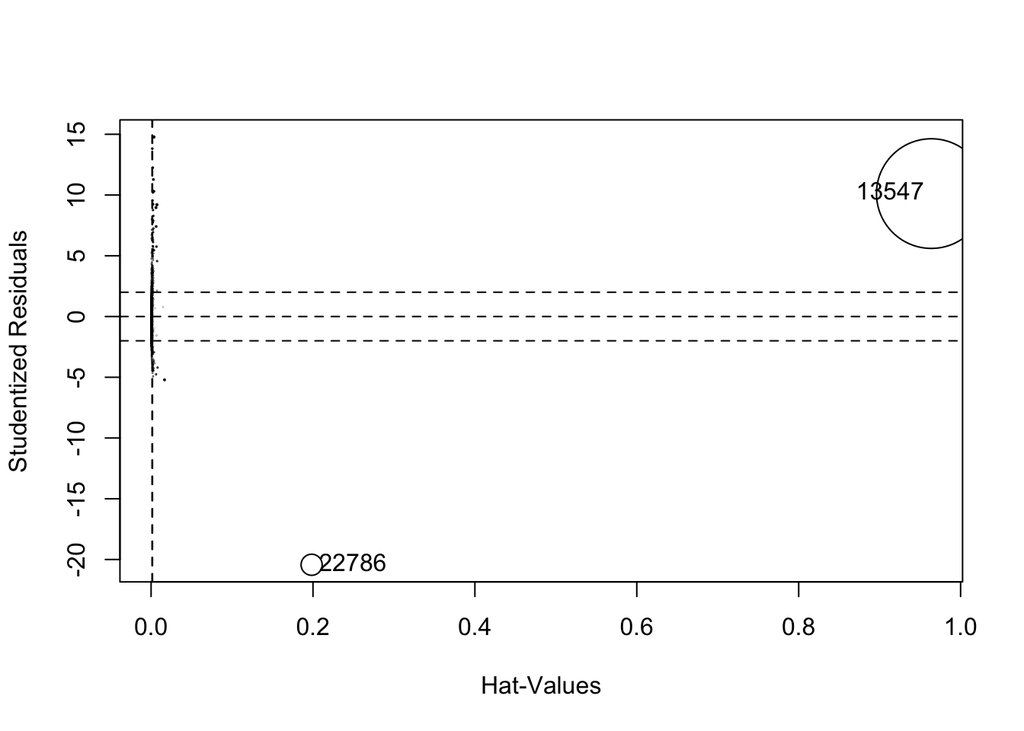

```
##         StudRes       Hat     CookD
## 13547  10.11849 0.9638689 338.90646
## 22786 -20.43393 0.1983324  12.53208
```

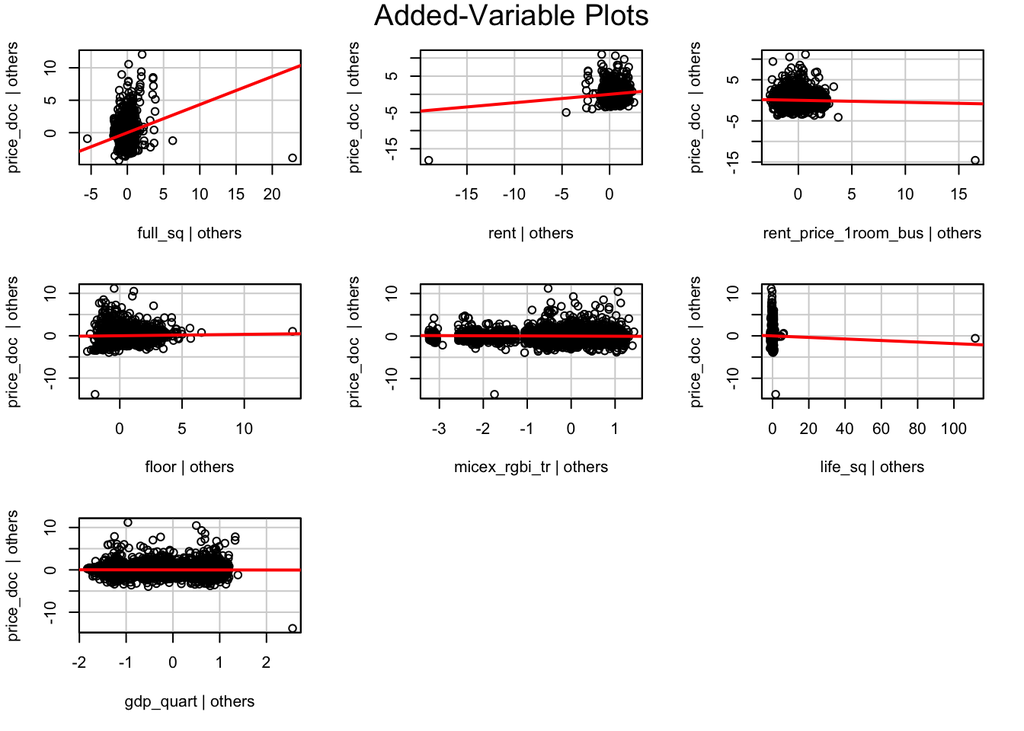

The backward stepwise regression proved computationally very inefficient (I will run later if I can for this document). It appears that regression is failing to extract signal from the macro data as it stands.

I’m going to try one linear regression of my own choosing:

```r
saturated_linear_regression = lm(price_doc ~ full_sq + life_sq + floor + max_floor + gdp_quart + usdrub + oil_urals + micex_rgbi_tr + rent + mortgage_rate, complete_stand_data[,2:ncol(complete_stand_data)])
summary(saturated_linear_regression)
```

```
##
## Call:
## lm(formula = price_doc ~ full_sq + life_sq + floor + max_floor +
##     gdp_quart + usdrub + oil_urals + micex_rgbi_tr + rent + mortgage_rate,
##     data = complete_stand_data[, 2:ncol(complete_stand_data)])
##
## Residuals:
##      Min       1Q   Median       3Q      Max
## -14.2882  -0.3275   0.0863   0.3120  11.1308
##
## Coefficients:
##                 Estimate Std. Error t value Pr(>|t|)
## (Intercept)    2.934e-15  6.526e-03   0.000 1.000000
## full_sq        4.561e-01  1.393e-02  32.739  < 2e-16 ***
## life_sq       -1.845e-02  6.716e-03  -2.747 0.006022 **
## floor          2.855e-02  7.718e-03   3.700 0.000217 ***
## max_floor      7.092e-03  7.801e-03   0.909 0.363283
## gdp_quart     -2.710e-02  9.311e-03  -2.910 0.003617 **
## usdrub         1.091e-01  3.074e-02   3.549 0.000388 ***
## oil_urals      4.628e-02  2.781e-02   1.664 0.096153 .
## micex_rgbi_tr  2.700e-02  1.965e-02   1.374 0.169593
## rent           2.045e-01  1.405e-02  14.562  < 2e-16 ***
## mortgage_rate -2.875e-03  1.005e-02  -0.286 0.774760
## ---
## Signif. codes:  0 '***' 0.001 '**' 0.01 '*' 0.05 '.' 0.1 ' ' 1
##
## Residual standard error: 0.7646 on 13716 degrees of freedom
## Multiple R-squared:  0.4159, Adjusted R-squared:  0.4154
## F-statistic: 976.5 on 10 and 13716 DF,  p-value: < 2.2e-16
```

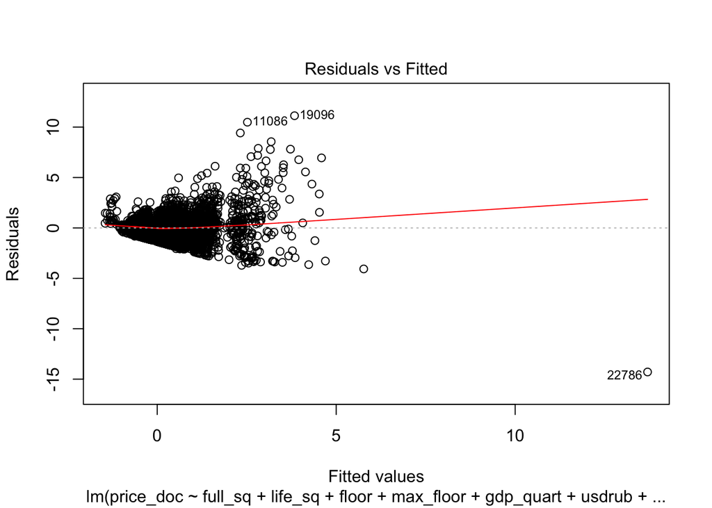

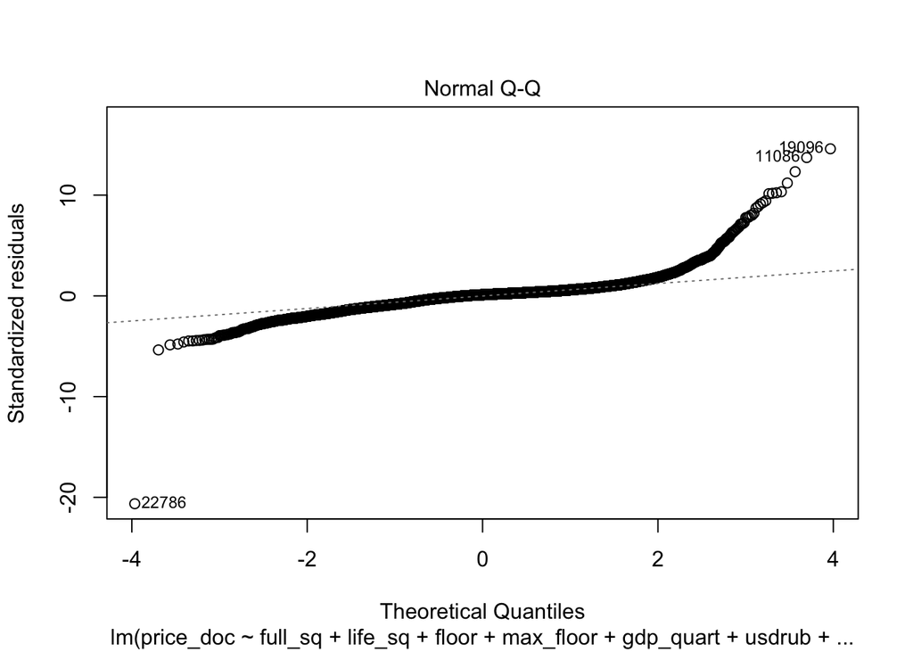

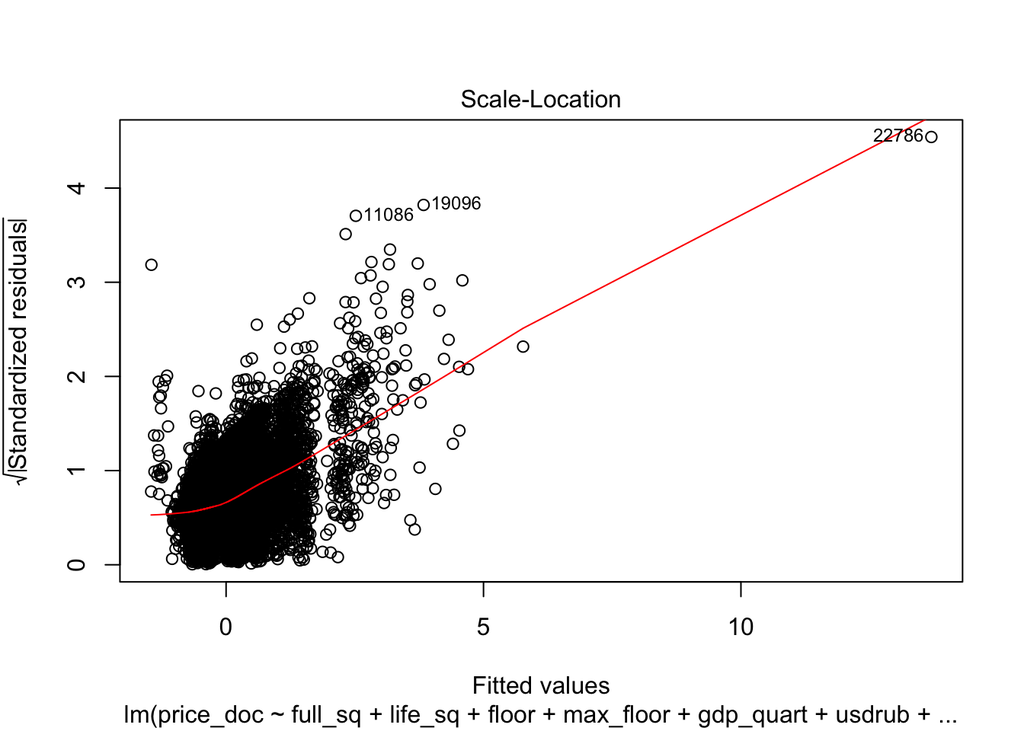

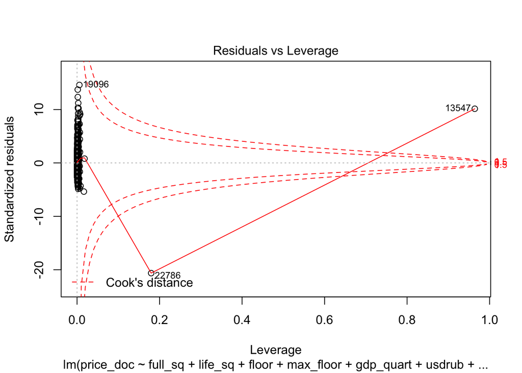

```r
plot(saturated_linear_regression)
```

R squared remains the same but plenty of variables show statistical significance.

I will attempt a random forest for the first, more sophisticated, non-linear learner:

```r
set.seed(0)
complete_stand_data$`rent_price_4+room_bus` = NULL
#Re-name at a later point.
rf.complete_stand_data = randomForest(price_doc ~ ., data = complete_stand_data[,2:ncol(complete_stand_data)])
rf.complete_stand_data
varImpPlot(rf.complete_stand_data)
```

[output not shown]

Next, I attempt to train a neural network on the data:

```r
train.index = sample(1:13727, 13727*.50)
test.index = -train.index
n <- names(complete_data[,2:ncol(complete_data)])
f <- as.formula(paste("price_doc ~", paste(n[!n %in% "price_doc"], collapse = " + ")))
nn <- neuralnet(f,data=complete_data[,2:ncol(complete_data)],hidden=c(5,3),linear.output=T)
plot(nn)
```

Which sadly, the neural net did not converge on a regression value after training for over 45 minutes on my Macbook Pro. This likely relates to some tuning on the neuron configuration side and further transformation or paring of the data.

I’ll instead attempt an SVM that allows for non-linearity, which should produce similar performance to a neural net. Let’s first look at the linear SVM performance on 50% of the data:

```r
train.index = sample(1:13727, 13727*.50)
test.index = -train.index

svm.mmc.linear = svm(price_doc ~ .,
                     data = complete_data,
                     subset = train.index,
                     kernel = "linear",
                     cost = 1)
summary(svm.mmc.linear)
SVM_predicted = predict(svm.mmc.linear, )
```

[output not shown]

Final notes: I attempted PCA transformation and ICA selection of variables to improve linear regression. My variance explained actually became worse.